# Circular-economy scenario responses across closure and regional setups

Accepted-cache coverage, long-term transmission and financial endpoints

Published

October 1, 2026

## What is being compared

This report compares circular-economy interventions across the ready external closures and the EU/RoW and North/South regional setups. An **arm** is a named registry configuration of the R model, with its own calibrated workbook, closure and baseline. Gold settles an external imbalance through central-bank gold stocks; fiat uses the reserve holder’s foreign bills; OPENFIXG adjusts that region’s government spending; QUASIFLOAT adjusts the exchange rate. Those rules change both the transmission of an intervention and the financial stock in which its external effect accumulates.

The report includes only caches accepted by the run validator, and states missing or failed coverage explicitly. It is a dated snapshot of the batch, not a claim that unmeasured cells have zero responses. OPENFLEX has no stationary baseline and is excluded; OPENFIXR and EU2011/RoW remain excluded or dropped by the maintainer.

## Observed coverage and acceptance

Source: output/calibration/scenario_grid_responses_20261001_status.csv . Counts of scenarios 1–4 and 6–13 per arm; expected counts follow the explicit twelve-scenario plan.

| arm | accepted | failed | expected |
| --- | --- | --- | --- |
| revised | 12 | 0 | 12 |
| revised_ns | 12 | 0 | 12 |
| revised_openfix_fiat | 12 | 0 | 12 |
| revised_ns_openfix_fiat | 12 | 0 | 12 |
| revised_openfixg | 12 | 0 | 12 |
| revised_ns_openfixg | 12 | 0 | 12 |
| revised_quasifloat | 12 | 0 | 12 |
| revised_ns_quasifloat | 12 | 0 | 12 |

```
This snapshot contains 96 accepted scenario caches out of 96 planned arm/scenario pairs, counted from that status file.
```

`R/scenarios/check_grid_run.R` requires the declared shock and substitution intensity, a solved last period of 100, finite simulation entries after the initialization column, and agreement with the arm’s baseline before the shock. Its scaled maximum pre-shock difference is `max(abs(S-B)/pmax(1,abs(B)))`, with acceptance tolerance `1e-9`. First-column initialization ratios are excluded from the finiteness test. Archived inactive workbook override rows are explicitly identified; every current state row must be present. A failed or missing run is not used to compute a response.

The status snapshot above is captured by the response extractor, so this report’s coverage and response tables describe the same accepted-cache set. The batch finished with every planned pair accepted; the final queue status is `output/calibration/scenario_grid_20261001_status.csv`.

The execution queue is `tools/scenarios/run_ready_grid.py`, with at most two R solves at once and one fresh process per scenario. `R/scenarios/run_all_scenarios.R` uses the flash engine by default and resolves calibrated arm override rows before running. The optional price cache reuses a value only for an identical complete argument list. Its canonical scratch-run identity check is in `output/calibration/scenario_memo_verify_revised_10_current_support_20261001.log`; the initial dimensions-only failure against a cache retaining inactive overrides is preserved separately.

The code, workbook and baseline hashes used by the queue are in `output/calibration/scenario_grid_20261001_inputs.json`. Accepted shock SHA-256 values and validation messages are in the status CSV. `R/scenarios/report_ready_grid.R` rechecks those cache hashes before extracting this report’s response table.

## Response basis and long-term activity

For each accepted shock, the baseline is `output/scenarios/arms/<arm>/runs/baseline.RDS`, and the numerator is `shock_<scenario>_run.RDS` in the same directory. Percent responses are `100 × (scenario / own-arm baseline − 1)`. The long-term observation is period 90, matching the submitted comparison’s shock period 70 plus 20 periods. Baseline, scenario level, level difference, period and input paths remain columns of the extracted CSV. Near-zero denominators are left without a percent response; CAB and reserve/gold stocks are reported as level differences.

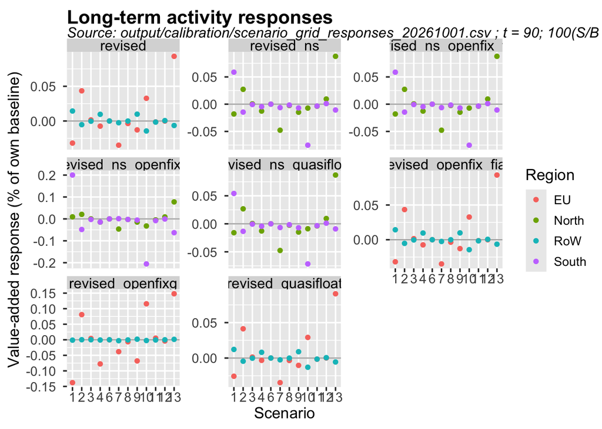

Source: output/calibration/scenario_grid_responses_20261001.csv ; variable va, period 90. Levels are nominal value added in each region’s model-currency units; percentages use its own arm baseline.

|  | arm | region | scenario | baseline | scenario_level | response_pct |
| --- | --- | --- | --- | --- | --- | --- |
| 1 | revised | EU | 1 | 1081.725 | 1081.381 | -0.031831 |
| 12 | revised | RoW | 1 | 3947.093 | 3947.661 | 0.014380 |
| 43 | revised | EU | 2 | 1081.725 | 1082.196 | 0.043487 |
| 54 | revised | RoW | 2 | 3947.093 | 3946.885 | -0.005279 |
| 85 | revised | EU | 3 | 1081.725 | 1081.742 | 0.001533 |
| 96 | revised | RoW | 3 | 3947.093 | 3947.081 | -0.000313 |
| 127 | revised | EU | 4 | 1081.725 | 1081.645 | -0.007415 |
| 138 | revised | RoW | 4 | 3947.093 | 3947.473 | 0.009630 |
| 169 | revised | EU | 6 | 1081.725 | 1081.725 | 0.000000 |
| 180 | revised | RoW | 6 | 3947.093 | 3947.093 | 0.000006 |
| 211 | revised | EU | 7 | 1081.725 | 1081.348 | -0.034847 |
| 222 | revised | RoW | 7 | 3947.093 | 3946.994 | -0.002494 |
| 253 | revised | EU | 8 | 1081.725 | 1081.687 | -0.003553 |
| 264 | revised | RoW | 8 | 3947.093 | 3947.091 | -0.000054 |
| 295 | revised | EU | 9 | 1081.725 | 1081.587 | -0.012803 |
| 306 | revised | RoW | 9 | 3947.093 | 3947.482 | 0.009848 |
| 337 | revised | EU | 10 | 1081.725 | 1082.079 | 0.032694 |
| 348 | revised | RoW | 10 | 3947.093 | 3946.525 | -0.014378 |
| 379 | revised | EU | 11 | 1081.725 | 1081.711 | -0.001364 |
| 390 | revised | RoW | 11 | 3947.093 | 3947.030 | -0.001606 |
| 421 | revised | EU | 12 | 1081.725 | 1081.725 | -0.000071 |
| 432 | revised | RoW | 12 | 3947.093 | 3947.116 | 0.000580 |
| 463 | revised | EU | 13 | 1081.725 | 1082.734 | 0.093196 |
| 474 | revised | RoW | 13 | 3947.093 | 3946.838 | -0.006466 |
| 505 | revised_ns | North | 1 | 3230.694 | 3230.113 | -0.017971 |
| 516 | revised_ns | South | 1 | 1575.565 | 1576.490 | 0.058696 |
| 549 | revised_ns | North | 2 | 3230.694 | 3231.574 | 0.027245 |
| 560 | revised_ns | South | 2 | 1575.565 | 1575.336 | -0.014550 |
| 593 | revised_ns | North | 3 | 3230.694 | 3230.711 | 0.000550 |
| 604 | revised_ns | South | 3 | 1575.565 | 1575.555 | -0.000621 |

[output cut: 162 more lines]

## Transmission labels and their limits

The submitted manuscript’s four assignments are reconstructed by `R/scenarios/transmission_regimes.R`. Its default threshold, τ = 0.003% of the absolute region-2 value-added response, was fitted to those submitted assignments. The rule first labels responses with |region-2 VA| < τ as SC. Above that threshold, region 1 contracting while region 2 expands gives production leakage (PL); region 1 expanding while region 2 contracts gives competitive displacement (CD), or fossil import collapse (FIC) for an energy shift. If both regions contract, the rule also gives symmetric contraction (SC); if both expand, it gives unclassified (UN). Thus SC combines a small-response branch and a both-regions-contract branch; only the latter establishes literal symmetric contraction. North/South labels apply the same rule to North and South; they are descriptive extensions of a submitted EU/RoW taxonomy.

Sources: per-arm transmission CSVs named in the last column. Percent VA responses at t = 90, own-model baselines; τ = 0.003% held fixed. Z1/Z2 are EU/RoW or North/South according to the arm.

|  | model | scenario | submitted_label | regime | va_Z1 | va_Z2 | source_file |
| --- | --- | --- | --- | --- | --- | --- | --- |
| revised.13 | revised | 1 | PL | PL | -0.031831 | 0.014380 | output/calibration/transmission_regimes_revised_20261001.csv |
| revised.14 | revised | 2 | FIC | FIC | 0.043487 | -0.005279 | output/calibration/transmission_regimes_revised_20261001.csv |
| revised.15 | revised | 3 | SC | SC | 0.001533 | -0.000313 | output/calibration/transmission_regimes_revised_20261001.csv |
| revised.16 | revised | 4 | PL | PL | -0.007415 | 0.009630 | output/calibration/transmission_regimes_revised_20261001.csv |
| revised.17 | revised | 6 | SC | SC | 0.000000 | 0.000006 | output/calibration/transmission_regimes_revised_20261001.csv |
| revised.18 | revised | 7 | SC | SC | -0.034847 | -0.002494 | output/calibration/transmission_regimes_revised_20261001.csv |
| revised.19 | revised | 8 | SC | SC | -0.003553 | -0.000054 | output/calibration/transmission_regimes_revised_20261001.csv |
| revised.20 | revised | 9 | PL | PL | -0.012803 | 0.009848 | output/calibration/transmission_regimes_revised_20261001.csv |
| revised.21 | revised | 10 | CD | CD | 0.032694 | -0.014378 | output/calibration/transmission_regimes_revised_20261001.csv |
| revised.22 | revised | 11 | SC | SC | -0.001364 | -0.001606 | output/calibration/transmission_regimes_revised_20261001.csv |
| revised.23 | revised | 12 | SC | SC | -0.000071 | 0.000580 | output/calibration/transmission_regimes_revised_20261001.csv |
| revised.24 | revised | 13 | FIC | FIC | 0.093196 | -0.006466 | output/calibration/transmission_regimes_revised_20261001.csv |
| revised_ns.13 | revised_ns | 1 | PL | PL | -0.017971 | 0.058696 | output/calibration/transmission_regimes_revised_ns_20261001.csv |
| revised_ns.14 | revised_ns | 2 | FIC | FIC | 0.027245 | -0.014550 | output/calibration/transmission_regimes_revised_ns_20261001.csv |
| revised_ns.15 | revised_ns | 3 | SC | SC | 0.000550 | -0.000621 | output/calibration/transmission_regimes_revised_ns_20261001.csv |
| revised_ns.16 | revised_ns | 4 | PL | SC | -0.012678 | -0.004658 | output/calibration/transmission_regimes_revised_ns_20261001.csv |
| revised_ns.17 | revised_ns | 6 | SC | SC | 0.000009 | 0.000009 | output/calibration/transmission_regimes_revised_ns_20261001.csv |
| revised_ns.18 | revised_ns | 7 | SC | SC | -0.047751 | -0.006293 | output/calibration/transmission_regimes_revised_ns_20261001.csv |
| revised_ns.19 | revised_ns | 8 | SC | SC | -0.002361 | -0.001603 | output/calibration/transmission_regimes_revised_ns_20261001.csv |
| revised_ns.20 | revised_ns | 9 | PL | SC | -0.014787 | -0.006923 | output/calibration/transmission_regimes_revised_ns_20261001.csv |
| revised_ns.21 | revised_ns | 10 | CD | SC | -0.007173 | -0.075224 | output/calibration/transmission_regimes_revised_ns_20261001.csv |
| revised_ns.22 | revised_ns | 11 | SC | SC | -0.003707 | -0.003478 | output/calibration/transmission_regimes_revised_ns_20261001.csv |
| revised_ns.23 | revised_ns | 12 | SC | SC | 0.009458 | 0.001075 | output/calibration/transmission_regimes_revised_ns_20261001.csv |
| revised_ns.24 | revised_ns | 13 | FIC | FIC | 0.087800 | -0.010672 | output/calibration/transmission_regimes_revised_ns_20261001.csv |
| revised_openfix_fiat.13 | revised_openfix_fiat | 1 | PL | PL | -0.031790 | 0.014343 | output/calibration/transmission_regimes_revised_openfix_fiat_20261001.csv |
| revised_openfix_fiat.14 | revised_openfix_fiat | 2 | FIC | FIC | 0.043443 | -0.005265 | output/calibration/transmission_regimes_revised_openfix_fiat_20261001.csv |
| revised_openfix_fiat.15 | revised_openfix_fiat | 3 | SC | SC | 0.001531 | -0.000312 | output/calibration/transmission_regimes_revised_openfix_fiat_20261001.csv |
| revised_openfix_fiat.16 | revised_openfix_fiat | 4 | PL | PL | -0.007424 | 0.009627 | output/calibration/transmission_regimes_revised_openfix_fiat_20261001.csv |
| revised_openfix_fiat.17 | revised_openfix_fiat | 6 | SC | SC | 0.000000 | 0.000006 | output/calibration/transmission_regimes_revised_openfix_fiat_20261001.csv |
| revised_openfix_fiat.18 | revised_openfix_fiat | 7 | SC | SC | -0.034847 | -0.002503 | output/calibration/transmission_regimes_revised_openfix_fiat_20261001.csv |

[output cut: 66 more lines]

For the completed fiat cells, the EU/RoW assignments remain unchanged. On North/South, scenarios 4, 9 and 10 have negative value-added responses in both regions and therefore receive SC through the rule’s both-regions-contract branch, instead of their submitted leakage or displacement assignments. Their absolute South responses exceed τ; these are not small-response classifications (the per-arm CSVs and table above give the exact values). This descriptive change does not identify a fiat effect: the submitted comparison also changes the regional workbook and the calibrated starting state.

Across the final grid, North/South gold and QUASIFLOAT also change scenarios 4, 9 and 10 to literal symmetric contraction. EU/RoW OPENFIXG changes scenarios 1, 2, 4, 9, 10 and 13 to SC through the small-RoW-response branch. North/South OPENFIXG changes scenarios 4, 9 and 10 to literal symmetric contraction, while scenario 1 expands in both regions and is UN. These are observations from the per-arm CSVs shown in the table, with the same period-90 own-baseline and fitted-threshold basis.

**Interpretation correction, 2026-10-02:** the earlier report and session commentary described the North/South fiat changes as small South responses. The values and classifier were correct, but that description omitted the both-negative branch of `R/scenarios/transmission_regimes.R`. The corrected explanation above preserves the numerical results and changes their interpretation.

An unchanged label does not establish an unchanged magnitude. A changed label does not attribute the change to a single equation revision, closure mechanism or regional coefficient; that would require an appropriate counterfactual.

## Financial endpoints and the fiat qualification

Source: output/calibration/scenario_grid_responses_20261001.csv ; period 100; each difference is scenario minus own-arm baseline. CAB and own bills use regional currency units; foreign-bill reserves are quantities in the issuer’s currency (Z1_b_cb_s_Z2 or Z2_b_cb_s_Z1), with absent mirror rows omitted; gold uses the model’s reserve-stock units, g uses model real-spending units, xr is a dimensionless exchange-rate quote.

|  | arm | region | scenario | variable | baseline | scenario_level | difference |
| --- | --- | --- | --- | --- | --- | --- | --- |
| 27 | revised | EU | 1 | b_s | 874.566536 | 877.818593 | 3.252057 |
| 28 | revised | EU | 1 | cab | -0.041277 | -0.177987 | -0.136710 |
| 29 | revised | EU | 1 | g | 240.000000 | 240.000000 | 0.000000 |
| 30 | revised | EU | 1 | xr | 1.000000 | 1.000000 | 0.000000 |
| 31 | revised | EU | 1 | or | 2103.413947 | 2099.517966 | -3.895982 |
| 32 | revised | EU | 1 | fx_res | 0.000000 | 0.000000 | 0.000000 |
| 38 | revised | RoW | 1 | b_s | 3359.677633 | 3356.566598 | -3.111035 |
| 39 | revised | RoW | 1 | cab | 0.041277 | 0.177987 | 0.136710 |
| 40 | revised | RoW | 1 | g | 675.000000 | 675.000000 | 0.000000 |
| 41 | revised | RoW | 1 | xr | 1.000000 | 1.000000 | 0.000000 |
| 42 | revised | RoW | 1 | or | 1896.585015 | 1900.480995 | 3.895981 |
| 69 | revised | EU | 2 | b_s | 874.566536 | 873.486028 | -1.080507 |
| 70 | revised | EU | 2 | cab | -0.041277 | 0.007219 | 0.048495 |
| 71 | revised | EU | 2 | g | 240.000000 | 240.000000 | 0.000000 |
| 72 | revised | EU | 2 | xr | 1.000000 | 1.000000 | 0.000000 |
| 73 | revised | EU | 2 | or | 2103.413947 | 2104.788761 | 1.374814 |
| 74 | revised | EU | 2 | fx_res | 0.000000 | 0.000000 | 0.000000 |
| 80 | revised | RoW | 2 | b_s | 3359.677633 | 3360.760077 | 1.082444 |
| 81 | revised | RoW | 2 | cab | 0.041277 | -0.007219 | -0.048495 |
| 82 | revised | RoW | 2 | g | 675.000000 | 675.000000 | 0.000000 |
| 83 | revised | RoW | 2 | xr | 1.000000 | 1.000000 | 0.000000 |
| 84 | revised | RoW | 2 | or | 1896.585015 | 1895.210201 | -1.374814 |
| 111 | revised | EU | 3 | b_s | 874.566536 | 874.480252 | -0.086283 |
| 112 | revised | EU | 3 | cab | -0.041277 | -0.037837 | 0.003440 |
| 113 | revised | EU | 3 | g | 240.000000 | 240.000000 | 0.000000 |
| 114 | revised | EU | 3 | xr | 1.000000 | 1.000000 | 0.000000 |
| 115 | revised | EU | 3 | or | 2103.413947 | 2103.518334 | 0.104386 |
| 116 | revised | EU | 3 | fx_res | 0.000000 | 0.000000 | 0.000000 |
| 122 | revised | RoW | 3 | b_s | 3359.677633 | 3359.766194 | 0.088561 |
| 123 | revised | RoW | 3 | cab | 0.041277 | 0.037837 | -0.003440 |

[output cut: 1074 more lines]

Fiat cases start from the calibrated zero-CAB knife-edge baseline. In the reserve mode, an imbalance can restart interest compounding, so a large endpoint stock change is compatible with a quiet unshocked baseline. It is not evidence that the shock has converged to a new stationary equilibrium. The North/South fiat baseline’s short reserve position remains an unresolved maintainer decision; running its scenarios does not endorse that position.

## Scenario 6 remains the existing intervention

The metal investment shift in `data/scenarios.csv`, scenario 6, changes `iota`. Under R9, replacement purchases follow the empirical capital matrix `K`, while `iota` allocates net investment (`id − da`). Near a stationary baseline, that flow is almost zero. The scenario therefore tests a much smaller purchase flow than its gross-investment interpretation in the submitted model. No scenario definition was changed in this batch. Redefining or dropping it remains the maintainer’s decision, and its near-inert response is not evidence that recycled-metal substitution in replacement capital has little effect.

## Runtime and what remains unestablished

Source: output/calibration/scenario_grid_responses_20261001_status.csv ; observed queue wall seconds for newly executed runs plus validation, including any temporary pause. Cached-reuse timings are excluded. These are not isolated CPU costs.

|  | arm | scenario | elapsed_seconds |
| --- | --- | --- | --- |
| 17 | revised_ns | 6 | 190.910 |
| 18 | revised_ns | 7 | 186.096 |
| 19 | revised_ns | 8 | 191.940 |
| 20 | revised_ns | 9 | 191.534 |
| 21 | revised_ns | 10 | 188.021 |
| 22 | revised_ns | 11 | 192.104 |
| 23 | revised_ns | 12 | 193.077 |
| 24 | revised_ns | 13 | 190.200 |
| 25 | revised_openfixg | 1 | 298.504 |
| 26 | revised_openfixg | 2 | 293.881 |
| 27 | revised_openfixg | 3 | 293.168 |
| 28 | revised_openfixg | 4 | 289.460 |
| 29 | revised_openfixg | 6 | 293.793 |
| 30 | revised_openfixg | 7 | 298.802 |
| 31 | revised_openfixg | 8 | 289.050 |
| 32 | revised_openfixg | 9 | 296.028 |
| 33 | revised_openfixg | 10 | 305.543 |
| 34 | revised_openfixg | 11 | 298.257 |
| 35 | revised_openfixg | 12 | 311.398 |
| 36 | revised_openfixg | 13 | 319.913 |
| 37 | revised_ns_openfixg | 1 | 446.901 |
| 38 | revised_ns_openfixg | 2 | 456.880 |
| 39 | revised_ns_openfixg | 3 | 468.679 |
| 40 | revised_ns_openfixg | 4 | 472.672 |
| 41 | revised_ns_openfixg | 6 | 456.595 |
| 42 | revised_ns_openfixg | 7 | 453.709 |
| 43 | revised_ns_openfixg | 8 | 450.766 |
| 44 | revised_ns_openfixg | 9 | 450.609 |
| 45 | revised_ns_openfixg | 10 | 435.538 |
| 46 | revised_ns_openfixg | 11 | 452.819 |
| 47 | revised_ns_openfixg | 12 | 459.045 |
| 48 | revised_ns_openfixg | 13 | 442.984 |
| 49 | revised_quasifloat | 1 | 193.997 |
| 50 | revised_quasifloat | 2 | 194.636 |
| 51 | revised_quasifloat | 3 | 195.810 |
| 52 | revised_quasifloat | 4 | 192.487 |
| 53 | revised_quasifloat | 6 | 193.574 |
| 54 | revised_quasifloat | 7 | 190.825 |
| 55 | revised_quasifloat | 8 | 190.654 |
| 56 | revised_quasifloat | 9 | 193.076 |
| 57 | revised_quasifloat | 10 | 192.687 |
| 58 | revised_quasifloat | 11 | 193.105 |
| 59 | revised_quasifloat | 12 | 191.278 |
| 60 | revised_quasifloat | 13 | 190.948 |
| 61 | revised_ns_quasifloat | 1 | 188.571 |
| 62 | revised_ns_quasifloat | 2 | 190.541 |
| 63 | revised_ns_quasifloat | 3 | 191.141 |
| 64 | revised_ns_quasifloat | 4 | 188.526 |
| 65 | revised_ns_quasifloat | 6 | 189.761 |
| 66 | revised_ns_quasifloat | 7 | 194.065 |
| 67 | revised_ns_quasifloat | 8 | 193.876 |
| 68 | revised_ns_quasifloat | 9 | 188.480 |
| 69 | revised_ns_quasifloat | 10 | 186.728 |
| 70 | revised_ns_quasifloat | 11 | 193.779 |
| 71 | revised_ns_quasifloat | 12 | 190.446 |
| 72 | revised_ns_quasifloat | 13 | 189.038 |
| 73 | revised_openfix_fiat | 1 | 266.594 |
| 74 | revised_openfix_fiat | 2 | 271.506 |
| 75 | revised_openfix_fiat | 3 | 206.242 |
| 76 | revised_openfix_fiat | 4 | 196.794 |
| 77 | revised_openfix_fiat | 6 | 199.734 |
| 78 | revised_openfix_fiat | 7 | 205.371 |
| 79 | revised_openfix_fiat | 8 | 188.130 |
| 80 | revised_openfix_fiat | 9 | 185.678 |
| 81 | revised_openfix_fiat | 10 | 189.258 |
| 82 | revised_openfix_fiat | 11 | 189.970 |
| 83 | revised_openfix_fiat | 12 | 191.090 |
| 84 | revised_openfix_fiat | 13 | 190.361 |
| 85 | revised_ns_openfix_fiat | 1 | 189.848 |
| 86 | revised_ns_openfix_fiat | 2 | 198.647 |
| 87 | revised_ns_openfix_fiat | 3 | 193.586 |
| 88 | revised_ns_openfix_fiat | 4 | 193.628 |
| 89 | revised_ns_openfix_fiat | 6 | 196.914 |
| 90 | revised_ns_openfix_fiat | 7 | 192.019 |
| 91 | revised_ns_openfix_fiat | 8 | 193.001 |
| 92 | revised_ns_openfix_fiat | 9 | 192.410 |
| 93 | revised_ns_openfix_fiat | 10 | 187.007 |
| 94 | revised_ns_openfix_fiat | 11 | 194.707 |
| 95 | revised_ns_openfix_fiat | 12 | 197.625 |
| 96 | revised_ns_openfix_fiat | 13 | 192.469 |

Accepted runs establish that the declared intervention reached the requested horizon under the engine’s solve checks. They do not prove asymptotic attraction, accounting-manifold stability or empirical identification of `par_xr`. The separate dynamics report documents reporting-stock modes, OPENFIXG’s precision-sensitive near-unit classification, and the distinction between the registry OPENFLEX experiment and its convergence diagnosis. The canonical premium with Ξ also remains open.